# Treatment Patterns in Atopic Dermatitis: A Synthetic EHR Cohort Analysis

Author

Shweta Yadav

Published

June 3, 2026

## Background

Atopic dermatitis (AD) is a chronic inflammatory skin condition managed in a stepwise way - starting with antihistamines for symptomatic relief, moving to topical steroids if needed, and escalating to systemic agents like cyclosporine only for refractory cases. In real-world practice, not every patient follows that textbook path, and tracing those deviations is part of what makes treatment pattern analysis useful.

This project uses synthetic EHR data generated by [Synthea](https://synthea.mitre.org/) to build a small AD cohort and trace medication history over time. The goal isn’t to draw statistical conclusions from 25 patients - it’s to practice the full RWE workflow: cohort definition, data quality checks, drug classification, and visualization. Because the data is entirely synthetic, it’s freely shareable and fully reproducible.

The Synthea simulation includes social determinants of health (SDOH) alongside clinical diagnoses - social isolation, stress, housing instability, and comorbid chronic conditions appear throughout this cohort, reflecting the realistic complexity seen in AD populations. These factors weren’t included in the current analysis but represent a meaningful dimension for future work.

## Data Source & Cohort Definition

1K Sample synthetic patient records were downloaded from Synthea, which simulates realistic clinical histories including diagnoses, medications, and encounters. Raw CSVs were loaded into a PostgreSQL database, cleaned, typed, and organized into a `core` schema before any analysis.

**Inclusion criteria:**

- At least one recorded diagnosis of Atopic Dermatitis (Synthea condition description match)
- Any age (pediatric patients are included but noted)

**Exclusion criteria:**

- None applied at this stage - this is a descriptive cohort, not an inferential study

This gave us **25 AD patients** in total. Three patients had no documented AD-related pharmacotherapy - they’re retained in the cohort but flagged as untreated.

## Data Quality & Fixes

Before any analysis, the database went through a systematic quality check. The full checks are in `sql/02_quality_checks.sql`. Three tables required corrections, documented in `sql/03_data_fixes.sql`. Original tables were preserved under renamed versions (e.g., `medications_original`, `observations_original`) so the cleaning steps are fully auditable.

**Business grain failures:**

- **Observations table** - 249 fully duplicate rows with no meaningful difference between records, suggesting a data source issue upstream in the Synthea simulation. These were removed and a clean table was created.
- **Medications table** - 24 duplicate rows where the only differences were in `base_cost` and `total_cost` columns. These were removed; the lower-cost record was retained as the canonical row.

**Date sanity failures:**

- **Medications table** - a small number of records had `stop_ts < start_ts` (reversed intervals). Obvious reversals were corrected where the intended direction was clear from context.
- **Claims transactions table** - similar date anomalies were found and corrected on the same basis.

Everything else passed - no duplicate primary keys, no orphaned medication or condition records, and no columns with critical null rates.

## Drug Classification

Raw Synthea medication descriptions are verbose (e.g., `"cetirizine hydrochloride 5 MG Oral Tablet"`). Drugs were mapped to a short name and a treatment step in the view `analytics.ad_medications_classified`, which also carries `encounter_id` and `reason_description` for downstream attribution checks.

| Treatment Step | Drug Class | Drugs in This Cohort |
| --- | --- | --- |
| 1 | Antihistamine | Cetirizine, Fexofenadine, Loratadine, Diphenhydramine, Chlorpheniramine |
| 2 | Topical Steroid | Hydrocortisone cream |
| 3 | Oral Steroid | Prednisone |
| 4 | Systemic Immunosuppressant | Cyclosporine |

The stepwise numbering mirrors the standard AD treatment ladder, making it straightforward to identify escalation patterns downstream.

## Analytical Assumptions

Before running analysis, a few upfront decisions shaped how the data was queried and interpreted.

**1. Patients may have multiple diagnoses.** The cohort was defined by the presence of an AD diagnosis, but patients aren’t exclusively AD patients. Several carry cardiovascular, metabolic, and respiratory conditions alongside AD. This is realistic and expected in any EHR dataset.

**2. Medication attribution confidence varies by drug class.** Investigating encounter reason codes showed that hydrocortisone and cyclosporine prescriptions were consistently linked to AD-coded encounters - high-confidence attribution. Antihistamine prescriptions had NULL encounter reasons or were linked to perennial allergic rhinitis encounters. All three patients in the rhinitis group carry a confirmed AD diagnosis (see Investigation Findings below), supporting their retention in the cohort. Prednisone records came from ER visits where encounter reason was not populated. Drug class filtering remains the primary attribution method; antihistamines should be interpreted as symptomatic controllers for the atopic disease spectrum rather than AD-exclusive therapy.

**3. Therapy sequences reflect prescription order, not confirmed clinical intent.** Sequences were derived by ordering medication start timestamps per patient. A patient who received an antihistamine for allergic rhinitis before their AD was formally coded would still appear as “Step 1: Antihistamine” in the treatment pathway analysis.

**4. Ongoing medications may be undercounted.** Synthea leaves `stop_ts` NULL for some active prescriptions. Duration calculations excluded these records, so average treatment durations may be slightly underestimated.

## Investigation Findings

These are things that surfaced during data exploration and changed the analysis approach.

**Finding 1: Medication-condition join on `patient_id` alone inflates counts.** The first version of the treatment query joined medications to conditions on `patient_id` only. A patient with AD and hypertension would have their lisinopril counted as an AD medication under this logic. The fix was to filter by drug class first, then join to the AD patient list. This materially changed drug counts and is documented in the cohort definition SQL.

**Finding 2: Cyclosporine appears under two spellings.** The raw data contains both `cyclosporine` and `cycloSPORINE modified` as distinct strings. Wrapping the LIKE filter in `lower()` catches both, but the inconsistency is worth knowing about if the dataset is ever extended.

**Finding 3: 17 of 25 AD patients initially appeared untreated - but weren’t.** The first drug filter covered only hydrocortisone, cyclosporine, and methotrexate. Expanding it to include antihistamines and prednisone reduced the untreated count from 17 to 3. Most patients were being managed with antihistamines - the original filter was simply too narrow.

**Finding 4: Encounter reason is not a reliable standalone attribution filter.** Encounter `reason_description` was checked to see whether it could strengthen drug attribution. Hydrocortisone and cyclosporine records were cleanly linked to AD encounters. However, non-AD drugs (amlodipine, lisinopril) also appeared in AD-coded encounters - because patients sometimes receive medication refills during disease-specific visits. And antihistamine encounters were either NULL or coded as rhinitis rather than AD. The encounter reason reflects why a patient came in, not the indication for each individual prescription. Drug class filtering is the more reliable approach for this dataset.

**Finding 5: Antihistamine prescriptions coded under rhinitis belong in the AD cohort.** Three patients had antihistamine prescriptions linked to perennial allergic rhinitis encounters. A check of their full condition lists confirmed all three carry an AD diagnosis, alongside significant comorbidity burden including obesity, prediabetes, chronic pain, and SDOH factors. The rhinitis coding reflects co-documentation - the antihistamine is treating the broader atopic disease burden, not a separate unrelated condition.

**Finding 6: The RA cohort was too small to analyze separately.** The 1,000-patient Synthea dataset included only 4 RA patients, 2 of whom had methotrexate records. Including RA as a separate cohort would have been misleading. The project was scoped to AD only.

## Patient Characteristics

````markdown
```{sql}
#| eval: false
#| label: sql-patient-summary
#| echo: true

-- Patient level summary:
-- Source: analytics.ad_cohort (cohort_definition.sql)
SELECT a.patient_id, a.birth_date, a.gender, a.race,
       EXTRACT(YEAR FROM AGE(CURRENT_DATE, a.birth_date)) AS age
FROM analytics.ad_cohort a;
```
````

```r
patients %>%
  mutate(
    gender = str_to_title(gender),
    race   = str_to_title(race)
  ) %>%
  select(age, gender, race) %>%
  tbl_summary(
    statistic = list(age ~ "{mean} ({sd})"),
    label = list(
      age    ~ "Age (years)",
      gender ~ "Sex",
      race   ~ "Race/Ethnicity"
    )
  ) %>%
  add_n() %>%
  bold_labels()
```

| **Characteristic** | **N** | **N = 25**<sup>1</sup> |
| --- | --- | --- |
| Age (years) | 25 | 31 (24) |
| Sex | 25 |  |
| F |  | 21 (84%) |
| M |  | 4 (16%) |
| Race/Ethnicity | 25 |  |
| Asian |  | 4 (16%) |
| Hawaiian |  | 1 (4.0%) |
| White |  | 20 (80%) |

<sup>1</sup> Mean (SD); n (%)

## Treatment Distribution

````markdown
```{sql}
#| eval: false
#| label: sql-treatment-distribution
#| echo: true

-- Age distribution of treated vs. untreated AD patients:
-- Source: ad_cohort (cohort_definition.sql); analytics.ad_medications_classified (treatment_classification.sql)
SELECT
    CASE WHEN amc.patient_id IS NOT NULL THEN 'Treated' ELSE 'Untreated' END AS treatment_status,
    ROUND(AVG(EXTRACT(YEAR FROM AGE(CURRENT_DATE, a.birth_date))), 1) AS avg_age,
    COUNT(DISTINCT a.patient_id) AS n
FROM analytics.ad_cohort a
LEFT JOIN analytics.ad_medications_classified amc ON a.patient_id = amc.patient_id
GROUP BY 1;
```
````

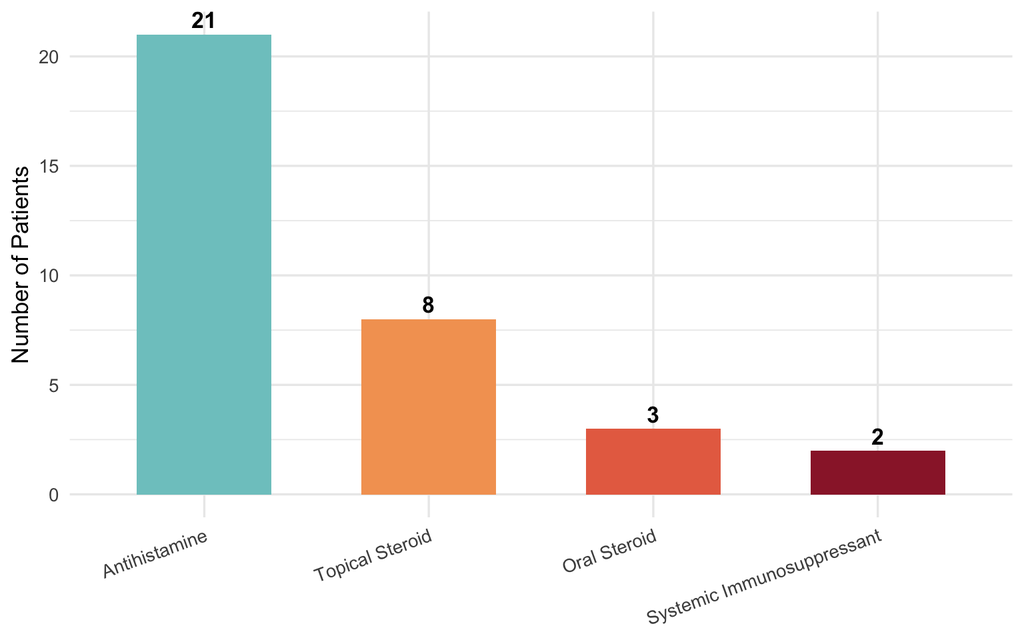

Number of unique AD patients receiving each drug class. Patients can appear in multiple bars if they received more than one drug class.

```r
timeline %>%
  distinct(patient_id, drug_class) %>%
  count(drug_class) %>%
  ggplot(aes(x = drug_class, y = n, fill = drug_class)) +
  geom_col(width = 0.6) +
  geom_text(aes(label = n), vjust = -0.4, size = 4.5, fontface = "bold") +
  scale_fill_manual(values = c(
    "Antihistamine"              = "#7EC8C8",
    "Topical Steroid"            = "#F4A261",
    "Oral Steroid"               = "#E76F51",
    "Systemic Immunosuppressant" = "#9B2335"
  )) +
  labs(x = NULL, y = "Number of Patients") +
  theme_minimal(base_size = 13) +
  theme(legend.position = "none",
        axis.text.x = element_text(angle = 20, hjust = 1))
```

The treatment distribution follows the expected stepwise pattern: antihistamines were used in 21 patients, topical steroids in 8, oral steroids in 3, and cyclosporine in only 2. Fewer patients needed each successive line of therapy, which is what we’d expect in a population where most AD is manageable without systemic immunosuppression.

## Therapy Sequences

Of the 22 treated patients, **11 had documented transitions between drug classes** - they received more than one type of AD medication over their follow-up period.

````markdown
```{sql}
#| eval: false
#| label: sql-treatment-distribution
#| echo: true

-- Sequential therapy (deduplicated drug transitions)
-- Source: ad_cohort (cohort_definition.sql); analytics.ad_medications_classified (treatment_classification.sql)
WITH deduped AS (
    SELECT
        patient_id,
        drug_short_name,
        start_ts,
        LAG(drug_short_name) OVER (
            PARTITION BY patient_id ORDER BY start_ts
        ) AS prev_drug
    FROM analytics.ad_medications_classified
)
SELECT
    patient_id,
    STRING_AGG(drug_short_name, ' → ' ORDER BY start_ts) AS therapy_sequence
FROM deduped
WHERE prev_drug IS DISTINCT FROM drug_short_name
GROUP BY patient_id
HAVING COUNT(*) > 1;
```
````

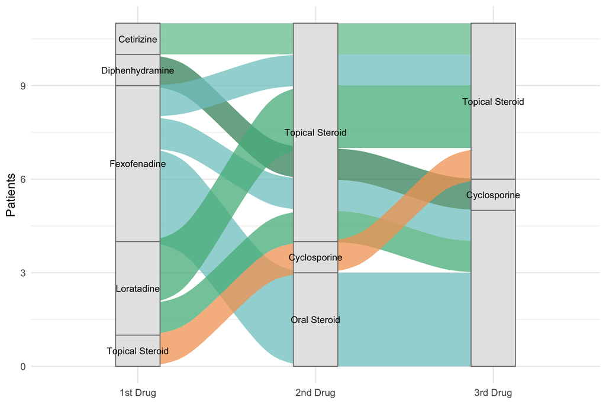

```r
alluvial_data <- sequences %>%
  mutate(therapy_sequence = str_replace_all(therapy_sequence, " → ", "→")) %>%
  separate_rows(therapy_sequence, sep = "→") %>%
  mutate(therapy_sequence = str_trim(therapy_sequence)) %>%
  group_by(patient_id) %>%
  mutate(step = paste0("Step ", row_number())) %>%
  ungroup() %>%
  pivot_wider(names_from = step, values_from = therapy_sequence) %>%
  filter(!is.na(`Step 2`)) %>%
  mutate(across(starts_with("Step"), ~case_when(
    str_detect(., "Hydrocortisone") ~ "Topical Steroid",
    str_detect(., "Cyclosporine")   ~ "Cyclosporine",
    str_detect(., "Prednisone")     ~ "Oral Steroid",
    TRUE ~ .
  ))) %>%
  count(`Step 1`, `Step 2`, `Step 3`, name = "freq")

ggplot(alluvial_data,
       aes(axis1 = `Step 1`, axis2 = `Step 2`, axis3 = `Step 3`, y = freq)) +
  geom_alluvium(aes(fill = `Step 1`), width = 1/12, alpha = 0.75) +
  geom_stratum(width = 1/4, fill = "grey90", color = "grey50") +
  geom_text(stat = "stratum", aes(label = after_stat(stratum)), size = 3.5) +
  scale_x_discrete(limits = c("Step 1", "Step 2", "Step 3"),
                   labels = c("1st Drug", "2nd Drug", "3rd Drug")) +
  scale_fill_manual(values = c(
    "Fexofenadine"    = "#7EC8C8",
    "Loratadine"      = "#52B788",
    "Cetirizine"      = "#74C69D",
    "Diphenhydramine" = "#40916C",
    "Topical Steroid" = "#F4A261"
  )) +
  labs(x = NULL, y = "Patients") +
  theme_minimal(base_size = 13) +
  theme(legend.position = "none")
```

The dominant treatment pathway is antihistamine → topical steroid, seen in 7 patients. Three patients moved from fexofenadine directly to oral prednisone - skipping topical steroids, which may reflect more severe initial presentations in the synthetic record. One patient shows the full 3-step escalation: diphenhydramine → hydrocortisone → cyclosporine.

## Patient Timelines (Swimmer Plot)

The swimmer plot shows each patient’s medication history anchored to their first AD drug. Each dot is a prescription record; color indicates drug class.

````markdown
```{sql}
#| eval: false
#| label: sql-treatment-distribution
#| echo: true

-- Treatment timeline per patient (swimmer plot input)
-- Source: analytics.ad_medications_classified
SELECT
    patient_id,
    original_drug_name AS medication_description,
    start_ts,
    drug_class,
    treatment_step
FROM analytics.ad_medications_classified
ORDER BY patient_id, start_ts;
```
````

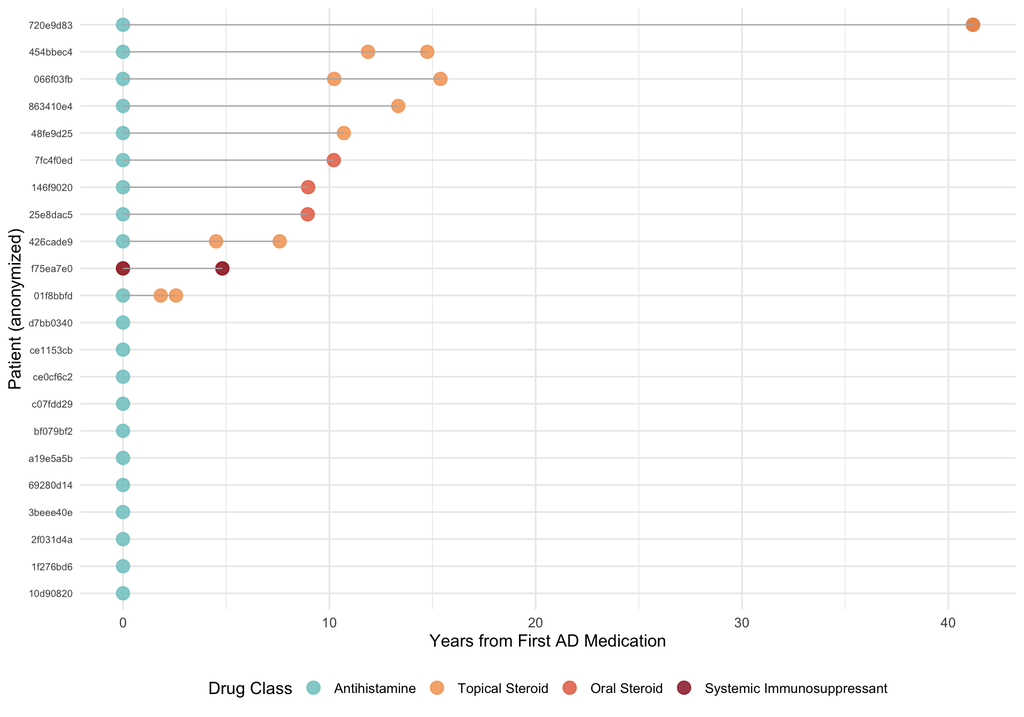

Per-patient treatment timelines anchored to first documented AD medication.

```r
swimmer_data <- timeline %>%
  group_by(patient_id) %>%
  mutate(
    index_date       = min(start_ts),
    years_from_index = as.numeric(difftime(start_ts, index_date, units = "days")) / 365.25
  ) %>%
  ungroup()

swimmer_data %>%
  ggplot(aes(x = years_from_index,
             y = reorder(patient_short, years_from_index),
             color = drug_class)) +
  geom_point(size = 4, alpha = 0.85) +
  geom_line(aes(group = patient_id), color = "grey70", linewidth = 0.4) +
  scale_color_manual(values = c(
    "Antihistamine"              = "#7EC8C8",
    "Topical Steroid"            = "#F4A261",
    "Oral Steroid"               = "#E76F51",
    "Systemic Immunosuppressant" = "#9B2335"
  )) +
  labs(
    x     = "Years from First AD Medication",
    y     = "Patient (anonymized)",
    color = "Drug Class"
  ) +
  theme_minimal(base_size = 12) +
  theme(legend.position = "bottom",
        axis.text.y = element_text(size = 7))
```

## Limitations

**Small sample size.** With 25 AD patients, all results are descriptive observations. Nothing here should be read as a generalizable finding - the goal of this project is to demonstrate the analytical workflow, not draw clinical conclusions.

**Synthetic data doesn’t capture prescribing nuance.** Synthea generates plausible medication records but doesn’t model dose adjustments, off-label use, adherence, or formulary constraints. Real-world prescribing is messier.

**No biologics.** Dupilumab and other IL-4/IL-13 inhibitors that dominate moderate-to-severe AD management today are absent from this Synthea simulation. The treatment landscape here reflects an older or milder AD population than a real-world claims dataset would show.

**Drug attribution is a proxy, not a confirmed indication.** Medications were classified by drug name pattern rather than a confirmed diagnosis-to-prescription link. Antihistamines in particular treat multiple atopic conditions and can’t be attributed to AD exclusively, even when the patient carries an AD diagnosis.

**Therapy sequences may include non-AD prescriptions.** Despite drug class filtering, some antihistamine prescriptions in the sequence were linked to rhinitis encounters. All such patients carry confirmed AD diagnoses, supporting their inclusion, but the clinical intent at the individual prescription level can’t be fully resolved from the data.

## Technical Notes

**Data pipeline:**

- Synthea v3 → raw CSV → PostgreSQL (`raw` schema) → typed and constrained (`core` schema)
- Key SQL files: `01_create_schema.sql`, `02_quality_checks.sql`, `03_data_fixes.sql`, `04_constraints_indexes.sql`, `05_ad_cohort_definition.sql`, `06_treatment_classification.sql`
- AD Cohort View: `analytics.ad_cohort`
- Drug classification and attribution view: `analytics.ad_medications_classified`
- Original pre-fix tables preserved as `medications_original`, `observations_original`